# Part II - ANALYZING FORD GOBIKE SYSTEM DATA

## by Paul Wainaina

## Investigation Overview

In this investigation I want to focus on the distribution of some variables present in the Forgo Bike dataset which include the user-type(Subscriber, Customer), gender(Male, Female, Other), age and how they relate with the trip duration of forgo bike in San Francisco.

## Dataset Overview

The dataset is from a sharing bicycle system called Ford GoBike. It is located in San Francisco bay area.

The dataset contains information about the GoBike system rides and it has around 183412 records and 18 features. I will focus on accessing the dataset to perform data wrangling and data visualization analysis process.

## USER-TYPE DISTRIBUTION

Most users in the bike sharing system is the subscriber with 90.5% as compared to the customer with 9.5%. This means that most bike users have subscribed to the bike sharing system.

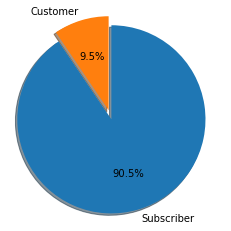

## GENDER DISTRIBUTION

In this dataset we will be comparing three entries for gender, female, male and other. The main focus is to determine the gender distribution in the bike sharing system.

Males use the bikes more as compared to females and other gender. Over 120000 users are males.

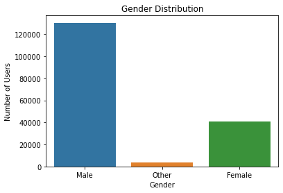

## DISTRIBUTION OF THE TRIP DURATION IN MINUTES

The trip duration represents the time taken to complete a trip. Analysing the trip duration taken by users in the forgo bike bike sharing system, most users tend to spend less than 30 minutes for a trip.

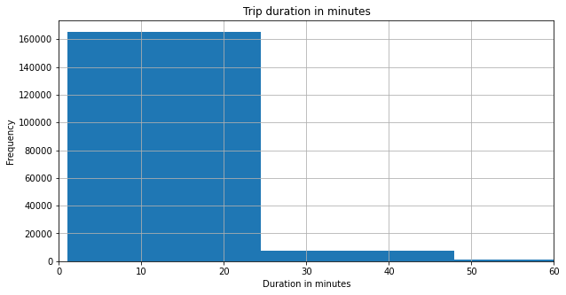

### TRIP DURATION FOR EACH GENDER IN MINUTES

Males take a shorter trip duration compared to the other gender.

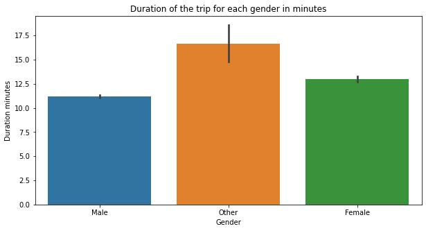